# Partitioning Families

In many cases, the connected families that we have to integrate over may be large but sparsely connected. As an example, consider the following three generation family:

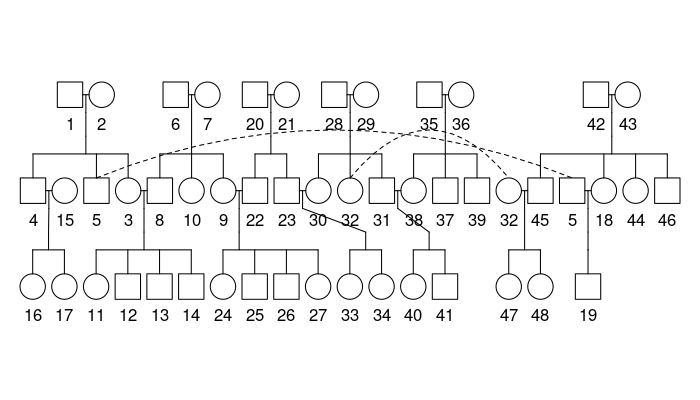

```r
# the data set we use
dat <- data.frame(
  id = 1:48,
  mom = c(NA, NA, 2L, 2L, 2L, NA, NA, 7L, 7L, 7L, 3L, 3L, 3L, 3L, NA, 15L, 15L, 43L, 18L, NA, NA, 21L, 21L, 9L, 9L, 9L, 9L, NA, NA, 29L, 29L, 29L, 30L, 30L, NA, NA, 36L, 36L, 36L, 38L, 38L, NA, NA, 43L, 43L, 43L, 32L, 32L),
  dad = c(NA, NA, 1L, 1L, 1L, NA, NA, 6L, 6L, 6L, 8L, 8L, 8L, 8L, NA, 4L, 4L, 42L, 5L, NA, NA, 20L, 20L, 22L, 22L, 22L, 22L, NA, NA, 28L, 28L, 28L, 23L, 23L, NA, NA, 35L, 35L, 35L, 31L, 31L, NA, NA, 42L, 42L, 42L, 45L, 45L),
  sex = c(1L, 2L, 2L, 1L, 1L, 1L, 2L, 1L, 2L, 2L, 2L, 1L, 1L, 1L, 2L, 2L, 2L, 2L, 1L, 1L, 2L, 1L, 1L, 2L, 1L, 1L, 2L, 1L, 2L, 2L, 1L, 2L, 2L, 2L, 1L, 2L, 1L, 2L, 1L, 2L, 1L, 1L, 2L, 2L, 1L, 1L, 2L, 2L))

# plot the pedigree
library(kinship2, quietly = TRUE)
ped <- with(dat, pedigree(id = id, dadid = dad, momid = mom, sex = sex))
par(mar = c(1, 1, 1, 1))
plot(ped)
```

In the plot, circles are females and squares are males. An individual may be repeated in which case duplicate entries are illustrated by a dashed line. If we observe outcomes for all 48 members of the family then we have to do 48 dimensional as everybody are marginally dependent if we have an additive genetic effect or similar effects. We assume that this is true in the rest of this vignette. Though it is possible also use the same method we describe here in other cases if one specifies a suitable graph, like the one we will get to soon, for the random effect structure.

To see that everybody are connected, notice that

- Child 16 is cousins with child 19 through her father.
- Child 19 is cousins with child 47 through his mom.
- Child 47 is cousins with child 33 through her mother.
- Child 33 is cousins with child 25 through her father.
- Child 25 is cousins with child 11 through his mother. At this point, we can realize that we are able to get to every individual in the pedigree starting at any point.
- Child 11 is cousins with child 16 through her mother and this leads us back to where we started and we have circle.

The relationships can also be represented as graph. For this purposes, we assign the functions below to create a list of edges between parents and their children. You can likely skip the functions.

```r
# returns the mothers id.
#
# Args:
#   pedigree: the pedigree object.
get_momid <- function(peddat)
  with(peddat,
       vapply(mindex, function(x) if(x > 0L) id[x] else NA_integer_, 1L))

# returns the fathers id.
#
# Args:
#   pedigree: the pedigree object.
get_dadid <- function(peddat)
  with(peddat,
       vapply(findex, function(x) if(x > 0L) id[x] else NA_integer_, 1L))

# creates an edge list to pass to igraph. An edge is included between children
# and parents.
#
# Args:
#   pedigree: the pedigree object.
create_igraph_input <- function(peddat){
  id <- peddat$id
  father <- get_dadid(peddat)
  mother <- get_momid(peddat)

  # TODO: this is O(n^2)
  stopifnot(anyDuplicated(id) < 1)
  out <- lapply(id, function(x){
    # find the children
    children_idx <- which(x == father | x == mother)
    children <- if(length(children_idx) > 0)
      id[children_idx] else NULL

    # get the correct order (smallest first) and return
    is_larger <- x > children

    cbind(
      ifelse(is_larger, children, x        ),
      ifelse(is_larger, x       , children))
  })

  out <- do.call(rbind, out)
  as.data.frame(out[!duplicated(out), ])
}
```

The graph version of the family looks like this:

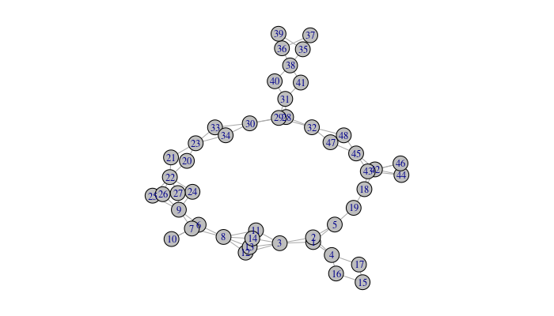

```r
# For some reason, kinship2::pedigree requires that we provide both a father
# and mother or none. Therefore, we create a mock object. You can skip this
get_pedigree_mock <- function(id, dadid, momid, sex){
  if(is.factor(sex))
    sex <- as.integer(sex)

  # checks
  n <- length(id)
  stopifnot(n > 0, length(dadid) == n, length(momid) == n, length(sex) == n,
            all(is.finite(sex)), all(sex %in% 1:2),
            all(is.na(dadid) | dadid %in% id),
            all(is.na(momid) | momid %in% id),
            all(is.finite(id)))

  # create objects to return
  findex <- match(dadid, id, nomatch = 0L)
  mindex <- match(momid, id, nomatch = 0L)

  structure(
    list(famid = rep(1L, n), id = id, findex = findex, mindex = mindex,
         sex = factor(sex, levels = 1:2, labels = c("male", "famle"))),
    class = "pedigree")
}

# assign function to plot the pedigree as a graph
do_graph_plot <- function(dat){
  ped <- with(dat, get_pedigree_mock(
    id = id, dadid = dad, momid = mom, sex = sex))
  library(igraph, quietly = TRUE)
  g_dat <- create_igraph_input(ped)
  graph_fam <-  graph.data.frame(g_dat, directed = FALSE)
  par(mar = c(1, 1, 1, 1))
  plot(graph_fam, vertex.size = 12, vertex.color = "gray",
       vertex.label.cex = .75, layout = layout_with_kk)
}
do_graph_plot(dat)
```

A node/vertex in the graph represents an individual and an edge indicates a parent-child relation. The graph have the property that if we split (find a connected partition of) the above into two sub-families (subgraphs) by removing child-parent relations (removing edges) then we only have to do two smaller integrals rather than one large. Having said that, the 48 dimensional integral that we show here is not a problem but higher dimensional integrals may be.

## Implemented Methods

The above suggests the following procedure for simplifying the computational problem:

1. Find a split (connected partition) such that the two sub-families (subgraphs) are roughly the same size (an approximately balanced partition).
2. Of the sets that satisfies 1., find the one that removes the least amount of relationships (cuts the least amount of edges).

We have implemented procedures to do just this. It also turns out that it is fine to not satisfy number 1. That is, to not get two connected sets in the partition. We will return to this later and to what we have implemented but first provide an example. We start by splitting the above family in way that only satisfies 1.:

```r
# get the partition
library(pedmod)
only_balanced <- max_balanced_partition_pedigree(
  id = dat$id, father.id = dat$dad, mother.id = dat$mom, trace = 2L)
```

```
#> Exited early. Balance criterion is 4
#> Exited early. Balance criterion is 7
#> Cannot improve balance criterion further
#> Found split. Balance criterion is 24
#> Found perfect balanced connected partition early. Balance criterion is 24
#> Found approximately balanced connected partition. Balance criterion is 24
```

```r
only_balanced$balance_criterion # the smallest of the two sets
```

```
#> [1] 24
```

```r
removed_edges <- only_balanced$removed_edges
removed_edges # the relationships we have removed
```

```
#>      from to
#> [1,]    6  8
#> [2,]    6 10
#> [3,]    7  9
#> [4,]   32 47
#> [5,]   32 48
```

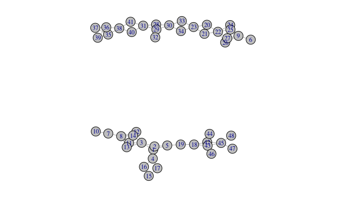

```r
# assign function to get the new data. You can likely skip this
get_reduced_data <- function(dat, removed_edges){
  for(i in 1:nrow(removed_edges)){
    . <- function(child, parent){
      idx   <- which(dat$id       == removed_edges[i, child])
      idx_m <- which(dat$mom[idx] == removed_edges[i, parent])
      if(length(idx_m > 0)){
        dat[idx[idx_m], "mom"] <<- NA_integer_
        return(TRUE)
      }
      idx_d <- which(dat$dad[idx] == removed_edges[i, parent])
      if(length(idx_d > 0)){
        dat[idx[idx_d], "dad"] <<- NA_integer_
        return(TRUE)
      }
      FALSE
    }
    if(.(1L, 2L))
      next
    .(2L, 1L)
  }

  dat
}
new_dat <- get_reduced_data(dat, removed_edges)

# redo the plot
do_graph_plot(new_dat)
```

The above shows the family after we remove the 5 relationships (edges) that our algorithm finds. To illustrate where the cut is in the original graph, we can color the vertices according to which set they are in:

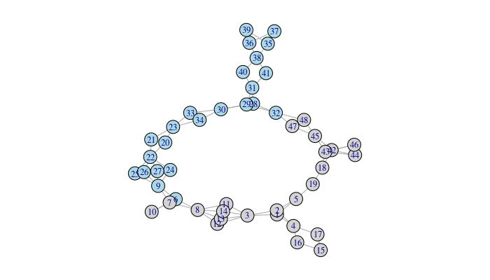

```r
# assign function to show the split in the original graph
show_split <- function(dat, partition_obj){
  ped <- with(dat, pedigree(id = id, dadid = dad, momid = mom, sex = sex))
  g_dat <- create_igraph_input(ped)
  graph_fam <-  graph.data.frame(g_dat, directed = FALSE)
  nam <- vertex_attr(graph_fam)$name
  V(graph_fam)$color[nam %in% partition_obj$set_1] <- "lightblue"
  V(graph_fam)$color[nam %in% partition_obj$set_2] <- "lightgray"
  par(mar = c(1, 1, 1, 1))
  plot(graph_fam, vertex.size = 12, vertex.label.cex = .75,
       layout = layout_with_kk)
}
show_split(dat, only_balanced)
```

### Reducing the Cut Cost

Next, we use the `slack` argument to reduce the number of relationships we remove (the number of edges we cut):

```r
also_cut <- max_balanced_partition_pedigree(
  id = dat$id, father.id = dat$dad, mother.id = dat$mom, trace = 2L,
  slack = .1)
```

```
#> Exited early. Balance criterion is 4
#> Exited early. Balance criterion is 7
#> Cannot improve balance criterion further
#> Found split. Balance criterion is 24
#> Found perfect balanced connected partition early. Balance criterion is 24
#> Found approximately balanced connected partition. Balance criterion is 24
#> Starting to reduce the cost of the cut in a block of size 38. The partition in the block consists of two sets of size 17 and 21. The cut cost is 5
#> Starting iteration 1
#> Found 6 vertices to move
#> Keept 2 moves with a gain of 1 and a balance criterion of 24
#> The cut cost is 4
#> Starting iteration 2
#> Found 6 vertices to move
#> Keept 0 moves
#> The cut cost is 4
```

```r
also_cut$balance_criterion # the smallest of the two sets
```

```
#> [1] 24
```

```r
removed_edges <- also_cut$removed_edges
removed_edges # the relationships we have removed
```

```
#>      from to
#> [1,]    6  9
#> [2,]    7  9
#> [3,]   32 48
#> [4,]   45 47
```

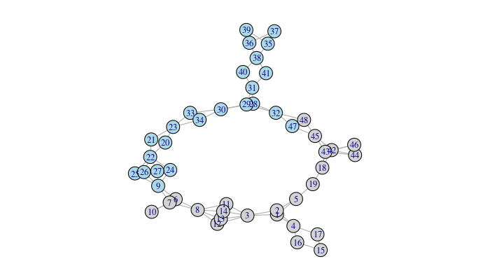

```r
# redo the plot
show_split(dat, also_cut)
```

We only removed 4 relationships (edges) this time.

### Using Individual Weights (Vertex Weights)

In many applications, we only observe some individuals. Therefore, we want the to split the family into equal sizes in terms of the individuals that we actually observe. We can do this by providing individual weights (vertex weights).

As an example, we will take the family we have been working with and assume that we only observe individuals in the final generation. Thus, we will set the weight of these individuals to a one and the remaining to some small positive number (say $10^{-5}$):

```r
# add the weights
is_final <- c(16:17, 11:14, 24:27, 33:34, 40:41, 47:48, 19L)
dat$id_weight <- ifelse(dat$id %in% is_final, 1., 1e-5)

weighted_partition <- max_balanced_partition_pedigree(
  id = dat$id, father.id = dat$dad, mother.id = dat$mom, trace = 2L,
  slack = .1, id_weight = dat$id_weight)
```

```
#> Exited early. Balance criterion is 4e-05
#> Exited early. Balance criterion is 2.00005
#> Cannot improve balance criterion further
#> Found split. Balance criterion is 8.00019
#> Exited early. Balance criterion is 2.00001
#> Found approximately balanced connected partition. Balance criterion is 8.00019
#> Starting to reduce the cost of the cut in a block of size 38. The partition in the block consists of two sets of size 20 and 18. The cut cost is 6
#> Starting iteration 1
#> Found 8 vertices to move
#> Keept 1 moves with a gain of 2 and a balance criterion of 8.00018
#> The cut cost is 4
#> Starting iteration 2
#> Found 7 vertices to move
#> Keept 0 moves
#> The cut cost is 4
```

```r
weighted_partition$balance_criterion # the smallest of the two sets
```

```
#> [1] 8
```

```r
removed_edges <- weighted_partition$removed_edges
removed_edges # the relationships we have removed
```

```
#>      from to
#> [1,]    6  8
#> [2,]    7  8
#> [3,]   32 47
#> [4,]   32 48
```

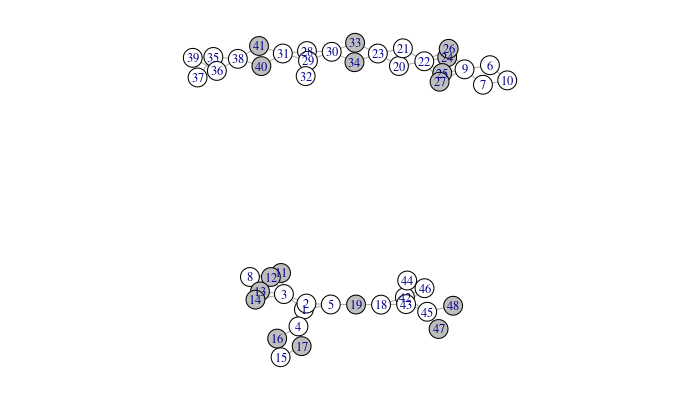

```r
# plot the new graph
plot_weighted <- function(dat, removed_edges){
  new_dat <- get_reduced_data(dat, removed_edges)
  ped <- with(new_dat, get_pedigree_mock(
    id = id, dadid = dad, momid = mom, sex = sex))
  g_dat <- create_igraph_input(ped)
  graph_fam <- graph.data.frame(g_dat, directed = FALSE)
  V(graph_fam)$color <- ifelse(vertex_attr(graph_fam)$name %in% is_final,
                               "gray", "white")
  par(mar = c(1, 1, 1, 1))
  plot(graph_fam, vertex.size = 12, vertex.label.cex = .75,
       layout = layout_with_kk)}

plot_weighted(dat, removed_edges)
```

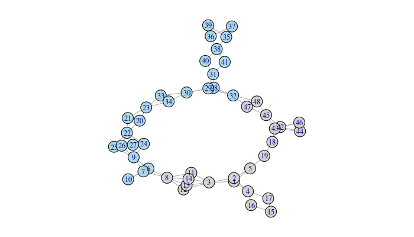

```r
show_split(dat, weighted_partition)
```

We have colored vertices which we observe in the first graph to make it easy to see that there is a as close as possible to an equal number in each sub-family.

### Using Relationship Weights (Edge Weights)

We can notice that the previous solution removes relations between the individuals we observe and their immediate ancestors. We can add a larger weight to these relationships to avoid or discourage this. To do so, we need to use the `father_weight` and `mother_weight` arguments as shown below:

```r
# add the weights
is_final <- c(16:17, 11:14, 24:27, 33:34, 40:41, 47:48, 19L)
dat$id_weight <- ifelse(dat$id %in% is_final, 1., 1e-5)

# add the edge weights
dat$father_weight <- dat$mother_weight <- ifelse(dat$id %in% is_final, 10., 1.)

# find the partition
weighted_partition <- max_balanced_partition_pedigree(
  id = dat$id, father.id = dat$dad, mother.id = dat$mom, trace = 2L,
  slack = .1, id_weight = dat$id_weight, father_weight = dat$father_weight,
  mother_weight = dat$mother_weight)
```

```
#> Exited early. Balance criterion is 4e-05
#> Exited early. Balance criterion is 2.00005
#> Cannot improve balance criterion further
#> Found split. Balance criterion is 8.00019
#> Exited early. Balance criterion is 2.00001
#> Found approximately balanced connected partition. Balance criterion is 8.00019
#> Starting to reduce the cost of the cut in a block of size 38. The partition in the block consists of two sets of size 20 and 18. The cut cost is 60
#> Starting iteration 1
#> Found 8 vertices to move
#> Keept 2 moves with a gain of 56 and a balance criterion of 8.00017
#> The cut cost is 4
#> Starting iteration 2
#> Found 6 vertices to move
#> Keept 0 moves
#> The cut cost is 4
```

```r
weighted_partition$balance_criterion # the smallest of the two sets
```

```
#> [1] 8
```

```r
removed_edges <- weighted_partition$removed_edges
removed_edges # the relationships we have removed
```

```
#>      from to
#> [1,]    6  8
#> [2,]    7  8
#> [3,]   28 32
#> [4,]   29 32
```

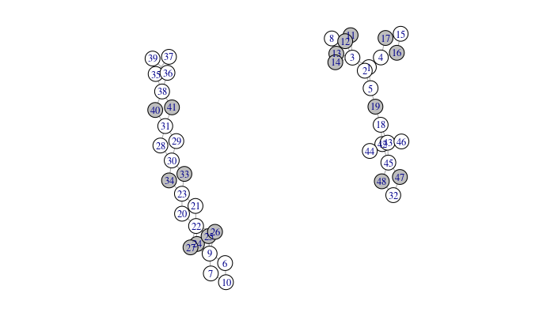

```r
# plot the new graph
plot_weighted(dat, removed_edges)
```

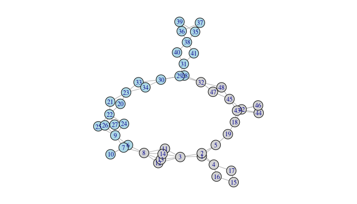

```r
show_split(dat, weighted_partition)
```

We end up cutting the link to the grandparents instead.

### Potentially Unconnected Partition

We may not require that the two sets in the partition is connected. The `unconnected_partition_pedigree` function does not impose this constraint. An example is given below:

```r
# without weights
partition <- unconnected_partition_pedigree(
  id = dat$id, father.id = dat$dad, mother.id = dat$mom, trace = 2L,
  slack = .1)
```

```
#> Starting from an initial paratition with a balance criterion of 0 with a total vertex weight of 48
#> The cut cost is 0
#> Starting to build the first partition that satisfy the balance criterion
#> Starting from an initial paratition with a balance criterion of 20 and a cut cost of 10
#> Starting iteration 1
#> Found 47 vertices to move
#> Keept 14 moves with a gain of 3 and a balance criterion of 24
#> The cut cost is 7
#> Starting iteration 2
#> Found 47 vertices to move
#> Keept 15 moves with a gain of 1 and a balance criterion of 21
#> The cut cost is 6
#> Starting iteration 3
#> Found 47 vertices to move
#> Keept 3 moves with a gain of 0 and a balance criterion of 24
#> The cut cost is 6
#> Starting iteration 4
#> Found 47 vertices to move
#> Keept 0 moves
#> The cut cost is 6
```

```r
partition$removed_edges # the relationships we have removed
```

```
#>      from to
#> [1,]    1  3
#> [2,]    2  3
#> [3,]   28 31
#> [4,]   29 31
#> [5,]   32 47
#> [6,]   32 48
```

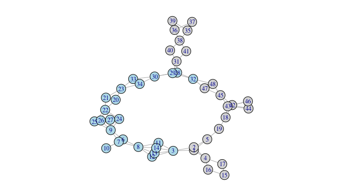

```r
# show the partition
show_split(dat, partition)
```

```r
# with weights
weighted_partition <- unconnected_partition_pedigree(
  id = dat$id, father.id = dat$dad, mother.id = dat$mom, trace = 2L,
  slack = .1, id_weight = dat$id_weight, father_weight = dat$father_weight,
  mother_weight = dat$mother_weight)
```

```
#> Starting from an initial paratition with a balance criterion of 0 with a total vertex weight of 17.0003
#> The cut cost is 0
#> Starting to build the first partition that satisfy the balance criterion
#> Starting from an initial paratition with a balance criterion of 7.00025 and a cut cost of 10
#> Starting iteration 1
#> Found 47 vertices to move
#> Keept 5 moves with a gain of 6 and a balance criterion of 7.0002
#> The cut cost is 4
#> Starting iteration 2
#> Found 47 vertices to move
#> Keept 0 moves
#> The cut cost is 4
```

```r
weighted_partition$removed_edges # the relationships we have removed
```

```
#>      from to
#> [1,]    1  5
#> [2,]    2  5
#> [3,]   20 22
#> [4,]   21 22
```

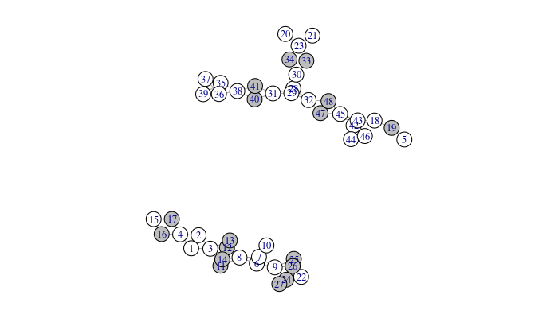

```r
# show the partition
plot_weighted(dat, weighted_partition$removed_edges)
```

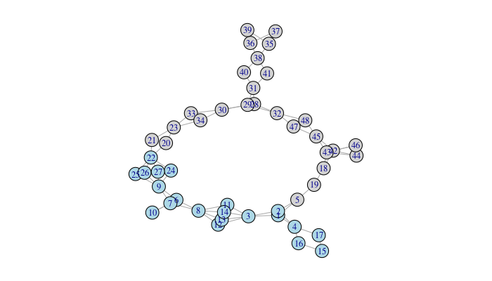

```r
show_split(dat, weighted_partition)
```

We can also start from a connected partition like below:

```r
# get the connected partition
connected_partition <- max_balanced_partition_pedigree(
  id = dat$id, father.id = dat$dad, mother.id = dat$mom, trace = 2L,
  slack = .1, id_weight = dat$id_weight, father_weight = dat$father_weight,
  mother_weight = dat$mother_weight)
```

```
#> Exited early. Balance criterion is 4e-05
#> Exited early. Balance criterion is 2.00005
#> Cannot improve balance criterion further
#> Found split. Balance criterion is 8.00019
#> Exited early. Balance criterion is 2.00001
#> Found approximately balanced connected partition. Balance criterion is 8.00019
#> Starting to reduce the cost of the cut in a block of size 38. The partition in the block consists of two sets of size 20 and 18. The cut cost is 60
#> Starting iteration 1
#> Found 8 vertices to move
#> Keept 2 moves with a gain of 56 and a balance criterion of 8.00017
#> The cut cost is 4
#> Starting iteration 2
#> Found 6 vertices to move
#> Keept 0 moves
#> The cut cost is 4
```

```r
# get the plausibly unconnected partition
partition <- unconnected_partition_pedigree(
  id = dat$id, father.id = dat$dad, mother.id = dat$mom, trace = 2L,
  slack = .1, id_weight = dat$id_weight, father_weight = dat$father_weight,
  mother_weight = dat$mother_weight, init = connected_partition$set_2)
```

```
#> Starting from an initial paratition with a balance criterion of 8.00017 with a total vertex weight of 17.0003
#> The cut cost is 4
#> Starting to build the first partition that satisfy the balance criterion
#> Starting from an initial paratition with a balance criterion of 8.00017 and a cut cost of 4
#> Starting iteration 1
#> Found 47 vertices to move
#> Keept 0 moves
#> The cut cost is 4
```

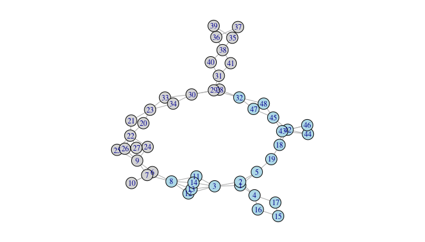

```r
# show the partition
show_split(dat, partition)
```

## Details

We will go through the details of the implemented methods in this section. All the methods we have implemented are for general graphs so we will cast the problem for a general graph $G = (V, E)$ with vertices $V$ and edges $E$ with some vertex weight function $w$. The first problem we need to solve is to implement a method to approximately solve the maximally balanced connected partition problem. That is, we want to find a partition ($V_1$, $V_2$) of the graph such that $V_1$ is connected and $V_2$ is connected. The partition we find needs to maximize $\min (w(V_1), w(V_2))$.

We have implemented the method suggested by Chlebíková (1996). This methods requires that one can find the cut vertices (articulation points) and can construct the block-cut tree. Thus, we have implemented the method suggested by Hopcroft and Tarjan (1973). The method suggested by Hopcroft and Tarjan (1973) can be accessed through the `biconnected_components` and `block_cut_tree` functions. We illustrate this below on a simulated graph:

```r
# simulates a connected graph of a given size
sim_graph <- function(size){
  stopifnot(size > 2)
  w_all <- (500:1)^(-2)
  out <- lapply(3:size, function(n){
    n_links <- sample.int(4L, 1L, prob = c(.5, .4, .05, .05))
    n_links <- min(n - 1L, n_links)
    idx_start <- max(1L, n - 500L)
    idx_end <- n - 1L
    prob <- if(n > 502L) w_all else (idx_end:idx_start)^(-2)
    cbind(from = n, to = sample(idx_start:idx_end, n_links, prob = prob))
  })
  out <- c(list(cbind(1L, 2L)), out)
  out <- do.call(rbind, out)
  ids <- sample.int(2L * size, size)
  out[] <- ids[out]
  out <- t(apply(out, 1L, sort))
  setNames(as.data.frame(out), c("from", "to"))
}
```

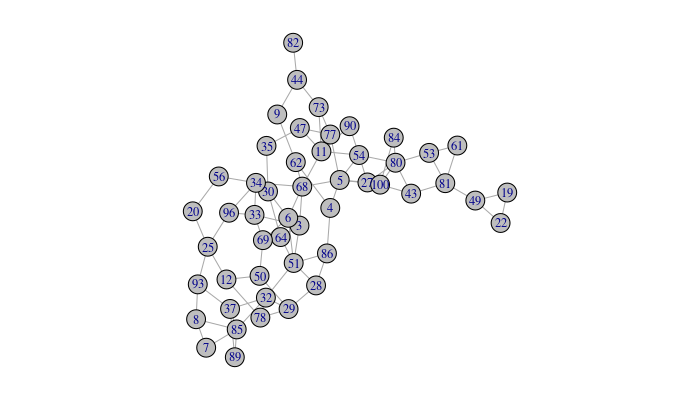

```r
# simulates a data set and illustrate it
set.seed(45L)
sim_dat <- sim_graph(50L)
par(mar = c(1, 1, 1, 1))
plot(graph.data.frame(sim_dat, directed = FALSE), layout = layout_with_kk,
     vertex.size = 12, vertex.color = "gray", vertex.label.cex = .75)
```

```r
# get the biconnected components
cut_pts <- biconnected_components(from = sim_dat$from, to = sim_dat$to)
length(cut_pts) # number of biconnected components
```

```
#> [1] 4
```

The algorithm suggested by Chlebíková (1996) can be used through the `max_balanced_partition` function with `slack == 0`:

```r
# find the approximately balanced connected partition
max_part <- max_balanced_partition(from = sim_dat$from, to = sim_dat$to,
                                   trace = 2L)
```

```
#> Exited early. Balance criterion is 2
#> Exited early. Balance criterion is 3
#> Cannot improve balance criterion further
#> Found split. Balance criterion is 25
#> Found perfect balanced connected partition early. Balance criterion is 25
#> Found approximately balanced connected partition. Balance criterion is 25
```

```r
max_part$balance_criterion # the balance criterion
```

```
#> [1] 25
```

```r
# the removed edges
removed_edges <- max_part$removed_edges
removed_edges
```

```
#>       from to
#>  [1,]    3  6
#>  [2,]    3 64
#>  [3,]    3 68
#>  [4,]    5 68
#>  [5,]    5 77
#>  [6,]    6 51
#>  [7,]    9 44
#>  [8,]   11 47
#>  [9,]   11 68
#> [10,]   11 73
#> [11,]   11 77
#> [12,]   28 29
#> [13,]   29 32
#> [14,]   32 37
#> [15,]   32 78
#> [16,]   32 85
#> [17,]   33 69
#> [18,]   33 96
#> [19,]   34 56
#> [20,]   34 68
#> [21,]   34 96
#> [22,]   51 64
#> [23,]   62 68
```

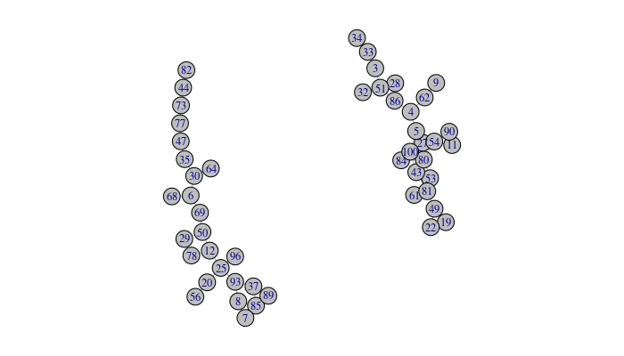

```r
# assign function to plot the partition
do_plot <- function(dat, partition_obj){
  removed_edges <- partition_obj$removed_edges

  to_remove <- apply(removed_edges, 1L, function(x)
    which(dat$from == x[1] & dat$to == x[2]))
  new_dat <- dat[-to_remove, ]
  par(mar = c(1, 1, 1, 1))
  plot(graph.data.frame(new_dat, directed = FALSE), layout = layout_with_kk,
       vertex.size = 12, vertex.color = "gray", vertex.label.cex = .75)
}
do_plot(sim_dat, max_part)
```

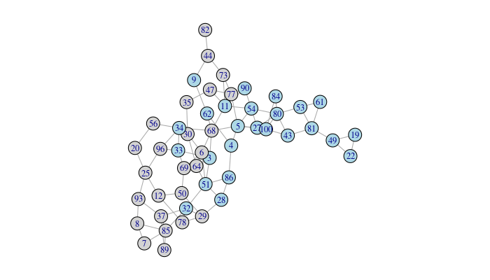

```r
# assign function to show the split in the original graph
show_split <- function(dat, partition_obj, vertex.size = 12,
                       vertex.label = NULL){
  graph_fam <-  graph.data.frame(dat, directed = FALSE)
  nam <- vertex_attr(graph_fam)$name
  V(graph_fam)$color[nam %in% partition_obj$set_1] <- "lightblue"
  V(graph_fam)$color[nam %in% partition_obj$set_2] <- "lightgray"
  par(mar = c(1, 1, 1, 1))
  plot(graph_fam, vertex.size = vertex.size, vertex.label.cex = .75,
       layout = layout_with_kk, vertex.label = vertex.label)
}
show_split(sim_dat, max_part)
```

Our implementation of the method by Chlebíková (1996) is outlined at Implementation Details. Currently, we re-compute the cut vertices (articulation points) at every iteration but it may be possible to update these which presumably will be faster and reduce the overall computation time. We do find a perfectly balanced partition above where each set is of size 25. However, we cut 23 edges to do this. Thus, we implemented a greedy method to reduce the number of cut edges while maintaining a roughly balanced connected partition which we outline next.

Given an approximately balanced connected partition $(V_1, V_2)$ and vertex weight function $w_H$ as defined by Chlebíková (1996), let $B$ be the block in which the partition is split, $\tilde V_1 = V_1 \cap B$ and $\tilde V_2 = V_2 \cap B$, and let $I_1 \subseteq \tilde V_2$ be the vertices that are connected with any vertex in $\tilde V_1$ and define $I_2$ similarly. Then

0. Compute the internal less external cost $D$ as in the Kernighan–Lin algorithm (Kernighan and Lin 1970).
1. Clear the set of used vertices.
2. For $i = 1,\dots,\min(\text{max moves},\text{vertices in }B)$:
   - Find the cut vertices $C_1$ of $\tilde V_1$ and $C_2$ of $\tilde V_2$.
   - Consider all the vertices in $I_1 \setminus C_2$ and $I_2 \setminus C_1$ such that the balance criteria $w_H(V) / 2 - \epsilon w_H(V) \leq w_H(\tilde V_1)$ and $w_H(\tilde V_1)\leq w_H(V) / 2 + \epsilon w_H(V)$ are satisfied for some user defined $\epsilon \in [0, .5)$ after the vertex is moved and that the vertex has not yet been used.
   - If there are no vertices satisfying this then exit.
   - Select the vertex $v$ with the largest $D_v$. Break ties by taking the $v$ with the largest balance criteria, $\min (w_H(\lvert \tilde V_1\rvert), w_H(\lvert \tilde V_2\rvert))$.
   - Let $g_i = D_v$ be the gain in this iteration, move the vertex $v$, update $I_1$, $I_2$, and $D$. Add $v$ to the used vertices.
3. If no vertex were moved then exit. Otherwise find the $l = \text{argmax}_{k = 1,\dots},\sum_{i = 1}^k g_i$. In case of ties, take the one with the highest balance criterion.
4. If $\sum_{i = 1}^l g_i \leq 0$ then undo all moves. Otherwise, undo moves after move $l$ and repeat 1.

The method is very similar to the original Kernighan–Lin algorithm. It differs by the constraint that the two sets in the partition should be connected, that we only move one vertex in every move (like Fiduccia and Mattheyses 1982), and that the partition is only approximately balanced (like Fiduccia and Mattheyses 1982). We also limit the number of moves we make as Karypis and Kumar (1998). Our implementations to find a potentially unconnected partition (`unconnected_partition` and `unconnected_partition_pedigree`) proceeds in a similar manner as above except that we do not require that the sets are connected. This substantially simplifies the algorithm.

$\epsilon$ is set with the `slack` argument of `max_balanced_partition` and the maximum number of moves to make in each iteration is set by the `max_kl_it_inner` argument of `max_balanced_partition`. We illustrate the method below:

```r
# do the same but with also with the refinement step
max_part <- max_balanced_partition(
  from = sim_dat$from, to = sim_dat$to, slack = .1, max_kl_it_inner = 50L,
  max_kl_it = 1000L, trace = 1L)
```

```
#> Found perfect balanced connected partition early. Balance criterion is 25
#> Found approximately balanced connected partition. Balance criterion is 25
#> Starting to reduce the cost of the cut in a block of size 46. The partition in the block consists of two sets of size 22 and 24. The cut cost is 23
#> Starting iteration 1
#> Found 46 vertices to move
#> Keept 6 moves with a gain of 9 and a balance criterion of 25
#> The cut cost is 14
#> Starting iteration 2
#> Found 46 vertices to move
#> Keept 15 moves with a gain of 6 and a balance criterion of 21
#> The cut cost is 8
#> Starting iteration 3
#> Found 46 vertices to move
#> Keept 6 moves with a gain of 3 and a balance criterion of 25
#> The cut cost is 5
#> Starting iteration 4
#> Found 46 vertices to move
#> Keept 0 moves
#> The cut cost is 5
```

```r
max_part$balance_criterion # the balance criterion
```

```
#> [1] 25
```

```r
removed_edges <- max_part$removed_edges
removed_edges
```

```
#>      from to
#> [1,]    3 68
#> [2,]    4 86
#> [3,]    6 68
#> [4,]   30 35
#> [5,]   34 68
```

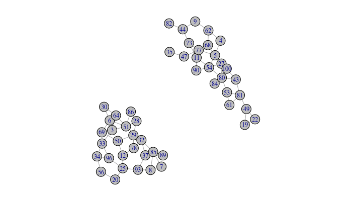

```r
# redo the plot
do_plot(sim_dat, max_part)
```

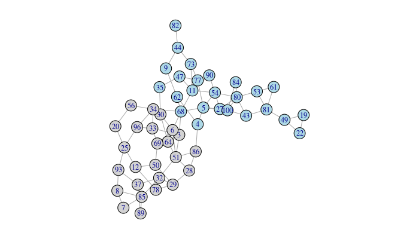

```r
show_split(sim_dat, max_part)
```

### Larger Example

We will take a larger example where we also focus on the computation time. The example is shown below:

```r
# simulate a data set with 1000 observations
set.seed(45L)
sim_dat <- sim_graph(1000L)

# get the biconnected components
cut_pts <- biconnected_components(from = sim_dat$from, to = sim_dat$to)
length(cut_pts) # number of biconnected components
```

```
#> [1] 56
```

```r
# find the approximately balanced connected partition
system.time(
  max_part <- max_balanced_partition(from = sim_dat$from, to = sim_dat$to,
                                     trace = 1L))
```

```
#> Found perfect balanced connected partition early. Balance criterion is 500
#> Found approximately balanced connected partition. Balance criterion is 500
#>    user  system elapsed
#>   0.088   0.000   0.088
```

```r
max_part$balance_criterion # the balance criterion
```

```
#> [1] 500
```

```r
NROW(max_part$removed_edges) # number of removed edges
```

```
#> [1] 282
```

```r
# improve on the number of cut vertices
system.time(
  max_part <- max_balanced_partition(from = sim_dat$from, to = sim_dat$to,
                                     trace = 1L, slack = .1,
                                     max_kl_it_inner = 1000L))
```

```
#> Found perfect balanced connected partition early. Balance criterion is 500
#> Found approximately balanced connected partition. Balance criterion is 500
#> Starting to reduce the cost of the cut in a block of size 940. The partition in the block consists of two sets of size 494 and 446. The cut cost is 282
#> Starting iteration 1
#> Found 876 vertices to move
#> Keept 207 moves with a gain of 143 and a balance criterion of 496
#> The cut cost is 139
#> Starting iteration 2
#> Found 713 vertices to move
#> Keept 69 moves with a gain of 34 and a balance criterion of 500
#> The cut cost is 105
#> Starting iteration 3
#> Found 806 vertices to move
#> Keept 30 moves with a gain of 6 and a balance criterion of 500
#> The cut cost is 99
#> Starting iteration 4
#> Found 845 vertices to move
#> Keept 0 moves
#> The cut cost is 99
#>    user  system elapsed
#>   0.891   0.000   0.891
```

```r
max_part$balance_criterion # the balance criterion
```

```
#> [1] 500
```

```r
NROW(max_part$removed_edges) # number of removed edges
```

```
#> [1] 99
```

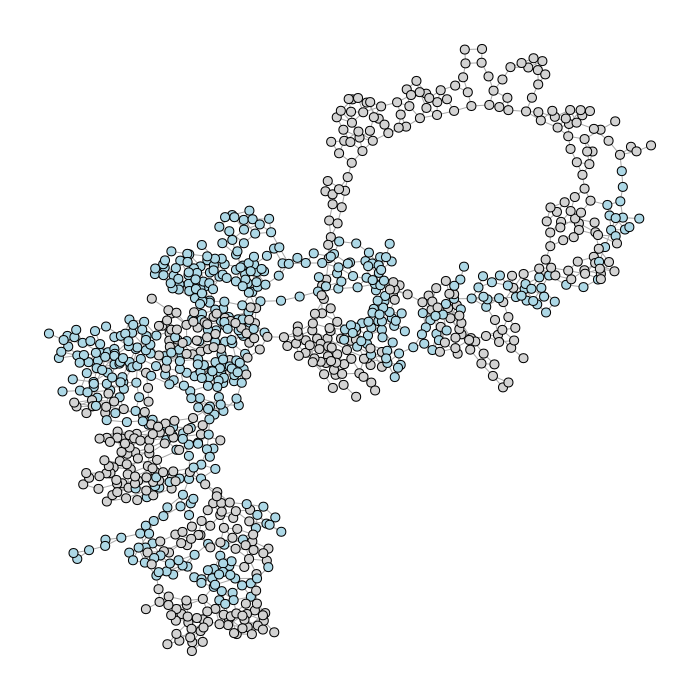

```r
# show the split
show_split(sim_dat, max_part, vertex.size = 3, vertex.label = NA)
```

We can also use the method for the potentially unconnected partition:

```r
# assign a variable with the connected partition
connected_partition <- max_part

# get the partition which may be unconnected
system.time(
  max_part <- unconnected_partition(from = sim_dat$from, to = sim_dat$to,
                                    trace = 1L, slack = .1,
                                    max_kl_it_inner = 1000L))
```

```
#> Starting from an initial paratition with a balance criterion of 0 with a total vertex weight of 1000
#> The cut cost is 0
#> Starting to build the first partition that satisfy the balance criterion
#> Starting from an initial paratition with a balance criterion of 400 and a cut cost of 75
#> Starting iteration 1
#> Found 999 vertices to move
#> Keept 135 moves with a gain of 40 and a balance criterion of 403
#> The cut cost is 35
#> Starting iteration 2
#> Found 999 vertices to move
#> Keept 10 moves with a gain of 5 and a balance criterion of 413
#> The cut cost is 30
#> Starting iteration 3
#> Found 999 vertices to move
#> Keept 975 moves with a gain of 11 and a balance criterion of 438
#> The cut cost is 19
#> Starting iteration 4
#> Found 999 vertices to move
#> Keept 0 moves
#> The cut cost is 19
#>    user  system elapsed
#>   0.006   0.000   0.006
```

```r
max_part$balance_criterion # the balance criterion
```

```
#> [1] 438
```

```r
NROW(max_part$removed_edges) # number of removed edges
```

```
#> [1] 19
```

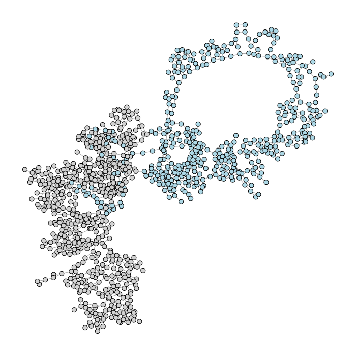

```r
# show the split
show_split(sim_dat, max_part, vertex.size = 3, vertex.label = NA)
```

```r
# we can start with random initialization
init <- unique(c(sim_dat$from, sim_dat$to))
init <- sample(init, ceiling(length(init) / 2))

system.time(
  max_part <- unconnected_partition(from = sim_dat$from, to = sim_dat$to,
                                    trace = 1L, slack = .1,
                                    max_kl_it_inner = 1000L,
                                    init = init))
```

```
#> Starting from an initial paratition with a balance criterion of 500 with a total vertex weight of 1000
#> The cut cost is 856
#> Starting to build the first partition that satisfy the balance criterion
#> Starting from an initial paratition with a balance criterion of 500 and a cut cost of 856
#> Starting iteration 1
#> Found 999 vertices to move
#> Keept 415 moves with a gain of 692 and a balance criterion of 491
#> The cut cost is 164
#> Starting iteration 2
#> Found 999 vertices to move
#> Keept 81 moves with a gain of 52 and a balance criterion of 500
#> The cut cost is 112
#> Starting iteration 3
#> Found 999 vertices to move
#> Keept 44 moves with a gain of 8 and a balance criterion of 492
#> The cut cost is 104
#> Starting iteration 4
#> Found 999 vertices to move
#> Keept 981 moves with a gain of 1 and a balance criterion of 473
#> The cut cost is 103
#> Starting iteration 5
#> Found 999 vertices to move
#> Keept 23 moves with a gain of 12 and a balance criterion of 480
#> The cut cost is 91
#> Starting iteration 6
#> Found 999 vertices to move
#> Keept 38 moves with a gain of 1 and a balance criterion of 442
#> The cut cost is 90
#> Starting iteration 7
#> Found 999 vertices to move
#> Keept 996 moves with a gain of 2 and a balance criterion of 438
#> The cut cost is 88
#> Starting iteration 8
#> Found 999 vertices to move
#> Keept 996 moves with a gain of 4 and a balance criterion of 434
#> The cut cost is 84
#> Starting iteration 9
#> Found 999 vertices to move
#> Keept 30 moves with a gain of 7 and a balance criterion of 452
#> The cut cost is 77
#> Starting iteration 10
#> Found 999 vertices to move
#> Keept 0 moves
#> The cut cost is 77
#>    user  system elapsed
#>   0.014   0.000   0.015
```

```r
max_part$balance_criterion # the balance criterion
```

```
#> [1] 452
```

```r
NROW(max_part$removed_edges) # number of removed edges
```

```
#> [1] 77
```

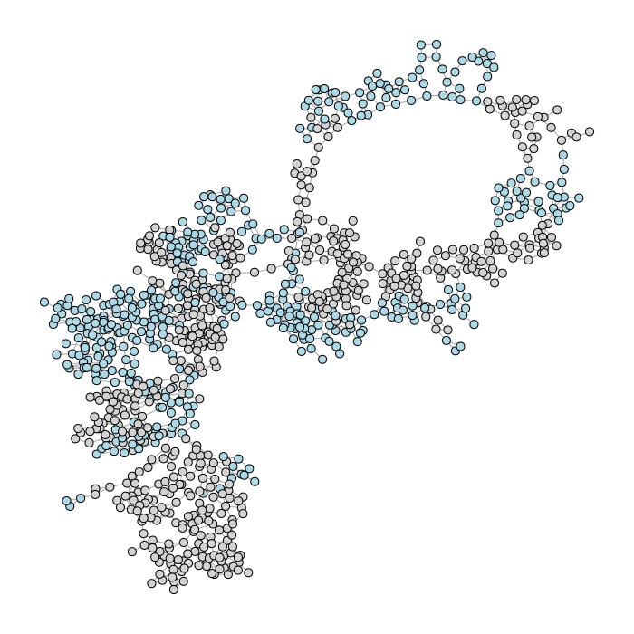

```r
# show the split
show_split(sim_dat, max_part, vertex.size = 3, vertex.label = NA)
```

```r
# we can also start from the connected partition
system.time(
  max_part <- unconnected_partition(from = sim_dat$from, to = sim_dat$to,
                                    trace = 1L, slack = .1,
                                    max_kl_it_inner = 1000L,
                                    init = connected_partition$set_1))
```

```
#> Starting from an initial paratition with a balance criterion of 500 with a total vertex weight of 1000
#> The cut cost is 99
#> Starting to build the first partition that satisfy the balance criterion
#> Starting from an initial paratition with a balance criterion of 500 and a cut cost of 99
#> Starting iteration 1
#> Found 999 vertices to move
#> Keept 79 moves with a gain of 30 and a balance criterion of 495
#> The cut cost is 69
#> Starting iteration 2
#> Found 999 vertices to move
#> Keept 990 moves with a gain of 4 and a balance criterion of 495
#> The cut cost is 65
#> Starting iteration 3
#> Found 999 vertices to move
#> Keept 17 moves with a gain of 2 and a balance criterion of 500
#> The cut cost is 63
#> Starting iteration 4
#> Found 999 vertices to move
#> Keept 52 moves with a gain of 6 and a balance criterion of 494
#> The cut cost is 57
#> Starting iteration 5
#> Found 999 vertices to move
#> Keept 8 moves with a gain of 9 and a balance criterion of 500
#> The cut cost is 48
#> Starting iteration 6
#> Found 999 vertices to move
#> Keept 0 moves
#> The cut cost is 48
#>    user  system elapsed
#>   0.009   0.000   0.010
```

```r
max_part$balance_criterion # the balance criterion
```

```
#> [1] 500
```

```r
NROW(max_part$removed_edges) # number of removed edges
```

```
#> [1] 48
```

```r
# compare with
NROW(connected_partition$removed_edges)
```

```
#> [1] 99
```

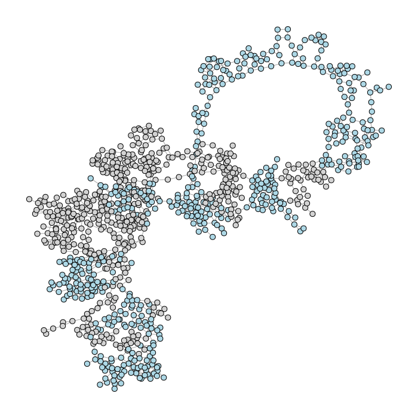

```r
show_split(sim_dat, max_part, vertex.size = 3, vertex.label = NA)
```

It is clear that the method is quite sensitive to the initialization.

### Even Larger Example

Here is an even larger example:

```r
# simulate a data set with 100000 observations
set.seed(45L)
sim_dat <- sim_graph(100000L)

# get the biconnected components
cut_pts <- biconnected_components(from = sim_dat$from, to = sim_dat$to)
length(cut_pts) # number of biconnected components
```

```
#> [1] 5694
```

```r
# find the approximately balanced connected partition
system.time(
  max_part <- max_balanced_partition(from = sim_dat$from, to = sim_dat$to,
                                     trace = 1L))
```

```
#> Found perfect balanced connected partition early. Balance criterion is 50000
#> Found approximately balanced connected partition. Balance criterion is 50000
#>    user  system elapsed
#>   4.829   0.000   4.829
```

```r
max_part$balance_criterion # the balance criterion
```

```
#> [1] 50000
```

```r
NROW(max_part$removed_edges) # number of removed edges
```

```
#> [1] 890
```

```r
# improve on the number of cut vertices
system.time(
  max_part <- max_balanced_partition(from = sim_dat$from, to = sim_dat$to,
                                     trace = 1L, slack = .1,
                                     max_kl_it_inner = 1000L))
```

```
#> Found perfect balanced connected partition early. Balance criterion is 50000
#> Found approximately balanced connected partition. Balance criterion is 50000
#> Starting to reduce the cost of the cut in a block of size 7270. The partition in the block consists of two sets of size 2484 and 4786. The cut cost is 890
#> Starting iteration 1
#> Found 1000 vertices to move
#> Keept 530 moves with a gain of 414 and a balance criterion of 49895
#> The cut cost is 476
#> Starting iteration 2
#> Found 1000 vertices to move
#> Keept 223 moves with a gain of 95 and a balance criterion of 50000
#> The cut cost is 381
#> Starting iteration 3
#> Found 1000 vertices to move
#> Keept 121 moves with a gain of 5 and a balance criterion of 49983
#> The cut cost is 376
#> Starting iteration 4
#> Found 1000 vertices to move
#> Keept 19 moves with a gain of 1 and a balance criterion of 50000
#> The cut cost is 375
#> Starting iteration 5
#> Found 1000 vertices to move
#> Keept 315 moves with a gain of 6 and a balance criterion of 49998
#> The cut cost is 369
#> Starting iteration 6
#> Found 1000 vertices to move
#> Keept 204 moves with a gain of 45 and a balance criterion of 49996
#> The cut cost is 324
#> Starting iteration 7
#> Found 1000 vertices to move
#> Keept 91 moves with a gain of 7 and a balance criterion of 49975
#> The cut cost is 317
#> Starting iteration 8
#> Found 1000 vertices to move
#> Keept 21 moves with a gain of 0 and a balance criterion of 50000
#> The cut cost is 317
#> Starting iteration 9
#> Found 1000 vertices to move
#> Keept 0 moves
#> The cut cost is 317
#>    user  system elapsed
#>   24.28    0.00   24.28
```

```r
max_part$balance_criterion # the balance criterion
```

```
#> [1] 50000
```

```r
NROW(max_part$removed_edges) # number of removed edges
```

```
#> [1] 317
```

The computation time may depend on the ordering of the data set. It may be advantageous to allow our implementation to re-order the vertices e.g. when they are completely randomly ordered. We can see this my shuffling the data:

```r
# shuffle the data
set.seed(1L)
sim_dat <- sim_dat[sample.int(NROW(sim_dat)), ]

# re-compute the partition without re-ordering the vertices
system.time(
  max_part_shuffled <- max_balanced_partition(
    from = sim_dat$from, to = sim_dat$to, trace = 1L, slack = .1,
    max_kl_it_inner = 1000L, do_reorder = FALSE))
```

```
#> Found perfect balanced connected partition early. Balance criterion is 50000
#> Found approximately balanced connected partition. Balance criterion is 50000
#> Starting to reduce the cost of the cut in a block of size 7270. The partition in the block consists of two sets of size 2491 and 4779. The cut cost is 967
#> Starting iteration 1
#> Found 1000 vertices to move
#> Keept 604 moves with a gain of 463 and a balance criterion of 49934
#> The cut cost is 504
#> Starting iteration 2
#> Found 1000 vertices to move
#> Keept 395 moves with a gain of 94 and a balance criterion of 49999
#> The cut cost is 410
#> Starting iteration 3
#> Found 1000 vertices to move
#> Keept 199 moves with a gain of 47 and a balance criterion of 49994
#> The cut cost is 363
#> Starting iteration 4
#> Found 1000 vertices to move
#> Keept 24 moves with a gain of 7 and a balance criterion of 50000
#> The cut cost is 356
#> Starting iteration 5
#> Found 1000 vertices to move
#> Keept 0 moves
#> The cut cost is 356
#>    user  system elapsed
#>   22.63    0.00   22.63
```

```r
max_part_shuffled$balance_criterion # the balance criterion
```

```
#> [1] 50000
```

```r
NROW(max_part_shuffled$removed_edges) # number of removed edges
```

```
#> [1] 356
```

```r
# re-compute the partition with re-ordering the vertices
system.time(
  max_part_shuffled_and_ordered <- max_balanced_partition(
    from = sim_dat$from, to = sim_dat$to, trace = 1L, slack = .1,
    max_kl_it_inner = 1000L, do_reorder = TRUE))
```

```
#> Found perfect balanced connected partition early. Balance criterion is 50000
#> Found approximately balanced connected partition. Balance criterion is 50000
#> Starting to reduce the cost of the cut in a block of size 7270. The partition in the block consists of two sets of size 2491 and 4779. The cut cost is 967
#> Starting iteration 1
#> Found 1000 vertices to move
#> Keept 604 moves with a gain of 463 and a balance criterion of 49934
#> The cut cost is 504
#> Starting iteration 2
#> Found 1000 vertices to move
#> Keept 395 moves with a gain of 94 and a balance criterion of 49999
#> The cut cost is 410
#> Starting iteration 3
#> Found 1000 vertices to move
#> Keept 199 moves with a gain of 47 and a balance criterion of 49994
#> The cut cost is 363
#> Starting iteration 4
#> Found 1000 vertices to move
#> Keept 24 moves with a gain of 7 and a balance criterion of 50000
#> The cut cost is 356
#> Starting iteration 5
#> Found 1000 vertices to move
#> Keept 0 moves
#> The cut cost is 356
#>    user  system elapsed
#>   20.89    0.00   20.89
```

```r
# we got the same
all.equal(max_part_shuffled_and_ordered, max_part_shuffled)
```

```
#> [1] TRUE
```

```r
# may not match!
all.equal(max_part, max_part_shuffled)
```

```
#> [1] "Component \"removed_edges\": Attributes: < Component \"dim\": Mean relative difference: 0.123 >"
#> [2] "Component \"removed_edges\": Numeric: lengths (634, 712) differ"
#> [3] "Component \"set_1\": Mean relative difference: 0.0006784"
#> [4] "Component \"set_2\": Mean relative difference: 0.0006786"
```

The solution will possibly not match when you reorder the data you pass to `max_balanced_partition`.

We can also compare the above with what we would have gotten if we had not required that the partition is connected.

```r
# assign a variable with the connected partition
connected_partition <- max_part_shuffled

# get potentially unconnected partition
system.time(
  max_part <- unconnected_partition(from = sim_dat$from, to = sim_dat$to,
                                    trace = 1L, slack = .1,
                                    max_kl_it_inner = 1000L))
```

```
#> Starting from an initial paratition with a balance criterion of 0 with a total vertex weight of 100000
#> The cut cost is 0
#> Starting to build the first partition that satisfy the balance criterion
#> Starting from an initial paratition with a balance criterion of 40000 and a cut cost of 7565
#> Starting iteration 1
#> Found 1000 vertices to move
#> Keept 1000 moves with a gain of 516 and a balance criterion of 40000
#> The cut cost is 7049
#> Starting iteration 2
#> Found 1000 vertices to move
#> Keept 1000 moves with a gain of 41 and a balance criterion of 40000
#> The cut cost is 7008
#> Starting iteration 3
#> Found 1000 vertices to move
#> Keept 6 moves with a gain of 2 and a balance criterion of 40000
#> The cut cost is 7006
#> Starting iteration 4
#> Found 1000 vertices to move
#> Keept 12 moves with a gain of 4 and a balance criterion of 40000
#> The cut cost is 7002
#> Starting iteration 5
#> Found 1000 vertices to move
#> Keept 432 moves with a gain of 9 and a balance criterion of 40000
#> The cut cost is 6993
#> Starting iteration 6
#> Found 1000 vertices to move
#> Keept 30 moves with a gain of 4 and a balance criterion of 40000
#> The cut cost is 6989
#> Starting iteration 7
#> Found 1000 vertices to move
#> Keept 32 moves with a gain of 15 and a balance criterion of 40000
#> The cut cost is 6974
#> Starting iteration 8
#> Found 1000 vertices to move
#> Keept 474 moves with a gain of 16 and a balance criterion of 40000
#> The cut cost is 6958
#> Starting iteration 9
#> Found 1000 vertices to move
#> Keept 112 moves with a gain of 16 and a balance criterion of 40000
#> The cut cost is 6942
```

[output cut: 51 more lines]

```
#> The cut cost is 6727
#> Starting iteration 23
#> Found 1000 vertices to move
#> Keept 530 moves with a gain of 8 and a balance criterion of 40000
#> The cut cost is 6719
#> Starting iteration 24
#> Found 1000 vertices to move
#> Keept 538 moves with a gain of 2 and a balance criterion of 40000
#> The cut cost is 6717
#> Starting iteration 25
#> Found 1000 vertices to move
#> Keept 0 moves
#> The cut cost is 6717
#>    user  system elapsed
#>   2.673   0.000   2.673
```

```r
max_part$balance_criterion # the balance criterion
```

```
#> [1] 40000
```

```r
NROW(max_part$removed_edges) # number of removed edges
```

```
#> [1] 6717
```

```r
# improve on the connected partition
system.time(
  max_part <- unconnected_partition(from = sim_dat$from, to = sim_dat$to,
                                    trace = 1L, slack = .1,
                                    max_kl_it_inner = 1000L,
                                    init = connected_partition$set_1))
```

```
#> Starting from an initial paratition with a balance criterion of 50000 with a total vertex weight of 100000
#> The cut cost is 356
#> Starting to build the first partition that satisfy the balance criterion
#> Starting from an initial paratition with a balance criterion of 50000 and a cut cost of 356
#> Starting iteration 1
#> Found 1000 vertices to move
#> Keept 162 moves with a gain of 73 and a balance criterion of 49910
#> The cut cost is 283
#> Starting iteration 2
#> Found 1000 vertices to move
#> Keept 90 moves with a gain of 11 and a balance criterion of 49926
#> The cut cost is 272
#> Starting iteration 3
#> Found 1000 vertices to move
#> Keept 27 moves with a gain of 0 and a balance criterion of 49953
#> The cut cost is 272
#> Starting iteration 4
#> Found 1000 vertices to move
#> Keept 92 moves with a gain of 3 and a balance criterion of 49861
#> The cut cost is 269
#> Starting iteration 5
#> Found 1000 vertices to move
#> Keept 82 moves with a gain of 0 and a balance criterion of 49943
#> The cut cost is 269
#> Starting iteration 6
#> Found 1000 vertices to move
#> Keept 0 moves
#> The cut cost is 269
#>    user  system elapsed
#>   0.570   0.000   0.571
```

```r
max_part$balance_criterion # the balance criterion
```

```
#> [1] 49943
```

```r
NROW(max_part$removed_edges) # number of removed edges
```

```
#> [1] 269
```

The method completely failed this time except when we started from the balanced connected partition.

### Implementation Details

The algorithm by Chlebíková (1996) is given below. Given a block (2-connected graph) $G=(V,E)$ and a vertex weight function $w$:

0. Order $V$ in such a way that $w(v_1) \geq w(v_2) \geq w(v_3) \geq \dots$.  
   Initialize $V_1 = \{v_1\}$ and $V_2 = V\setminus V_1$.
1. If $w(V_1) \geq w(V)/2$ then go to 3. else go to 2.
2. Let
   $$V_0 = \left\{u \in V_2 \mid \left(V_1 \cup \{u\}, V_2 \setminus \{u\}\right) \text{ is a connected partition of }G\right\}.$$
   Choose $u = \text{arg min}_{v\in V_0} w(v)$.
   If $w(u) < w(V) - 2w(V_1)$ then set $V_1 := V_1 \cup \{u\}$ and $V_2 := V_2 \setminus \{u\}$ and go to 1. else go to 3.
3. Return $(V_1, V_2)$.

The $V_1 \cup \{u\}$ condition in step 2. is easy to deal with as one can keep track of vertices that have neighbors in the other set. We cannot remove $u\in V_2$ in 2. if $u$ is an articulation point (cut vertex) of $V_2$ as then $V_2$ is no longer connected. Therefore, an implementation may look as follows:

0. Find $v_1 = \text{arg max}_{u \in V} w(u)$.
   Initialize $V_1 = \{v_1\}$ and $V_2 = V\setminus V_1$.
   Create the sets
   $$\begin{align*}
   I &= \left\{u \in V_2 \mid u \text{ has an edge to any vertex } v \in V_1\right\} \\
   A &= \left\{u \in V_2 \mid u \text{ is an articulation point of }V_2\right\}.
   \end{align*}$$
1. If $w(V_1) \geq w(V)/2$ then go to 4. else go to 2.
2. Let $V_0 = I \setminus A$. Choose $u = \text{arg min}_{v\in V_0} w(v)$.  
   If $w(u) < w(V) - 2w(V_1)$ then go to 3. else go to 4.
3. Set $V_1 := V_1 \cup \{u\}$ and $V_2 := V_2 \setminus \{u\}$.  
   Update $I$ and $A$ and go to 1.
4. Return $(V_1, V_2)$.

We can find the articulation points in $\mathcal O(\lvert V_2\rvert)$ using the method suggested by Hopcroft and Tarjan (1973) and we do not need to do anything for every vertex $u\in I$. Perhaps we can update $A$ quicker then this though.

## References

Chlebíková, Janka. 1996. “Approximating the Maximally Balanced Connected Partition Problem in Graphs.” *Information Processing Letters* 60 (5): 225–30. https://doi.org/10.1016/S0020-0190(96)00175-5.

Fiduccia, C.M., and R.M. Mattheyses. 1982. “A Linear-Time Heuristic for Improving Network Partitions.” In *19th Design Automation Conference*, 175–81. https://doi.org/10.1109/DAC.1982.1585498.

Hopcroft, John, and Robert Tarjan. 1973. “Algorithm 447: Efficient Algorithms for Graph Manipulation.” *Commun. ACM* 16 (6): 372–78. https://doi.org/10.1145/362248.362272.

Karypis, George, and Vipin Kumar. 1998. “A Fast and High Quality Multilevel Scheme for Partitioning Irregular Graphs.” *SIAM Journal on Scientific Computing* 20 (1): 359–92. https://doi.org/10.1137/S1064827595287997.

Kernighan, B. W., and S. Lin. 1970. “An Efficient Heuristic Procedure for Partitioning Graphs.” *The Bell System Technical Journal* 49 (2): 291–307. https://doi.org/10.1002/j.1538-7305.1970.tb01770.x.